# R Crawler 101: Week 3

play with facebook API and regular expression

Kyle Chung

Data Scientist, Trend Micro  
kylechun9@gmail.com

23 January, 2016

## Facebook Graph API | Introduction

### > the UI for exploration

- [Facebook Graph API Explorer](https://developers.facebook.com/tools/explorer)
  - need a valid *access token*
  - the token will expire in hour (and can be refreshed)

### > components of the API

- nodes
  - **objects**: a User, a Photo, a Page, a Comment, …
- edegs
  - **connections** between objects
- fields
  - **information** about objects

### > baisc syntax

`/<node_id>/<edge_name>?fields=f1,f2,...`

- try the special `me` node: `me/photos?fields=from`
- the `me` node resolves to id of the user that owns the current token

### > which field?

- not all fields are returned by default
- use query string `metadata=1` to show available fields/edges on a node
  - `<node_id>?metadata=1`
  - e.g.: `me?metadata=1`

### > nested query

- solution 1:
  - `<node_id>?fields=f1{subf1,subf2,...},f2,...`
  - e.g.: `me?fields=photos{from,id}`
- solution 2: (recommended)
  - `<node_id>?fields=f1.fields(subf1,subf2,...),f2,...`
  - e.g.: `me?fields=photos.fields(from,id)`
- no limit on the depth of nesting

### > node? edge?

- edge is the *population*, node is the *individual*
  - “all of my photos” => edge (no id)
  - “this photo of mine” => node (with id)
- fields are defined on nodes
- difference in syntax (and returned json):
  - field querying: `me?fields=photos{from}`
  - edge querying: `me/photos?fields=from`

### > query modifiers

#### >> limit

to restrict the number of records returned

- on field:
  - `me?fields=photos.limit(10)`
- on edge:
  - `me/photos?limit=10`

#### >> summary

to return a count for totals regardless of the actuall number of records returned

- on field:
  - `<photo_id>?fields=likes.summary(true)`
- on edge:
  - `<photo_id>/likes?summary=true`

#### >> since

to restrict the valid starting timeframe of the data returned

- on field:
  - won’t work
- on edge:
  - `me/posts?since=1420070400`
- [unix time converter](http://www.epochconverter.com)
- what is unix time?
  - total seconds elapsed since 1970-01-01 UTC time
  - 1420070400 is 2015-01-01 UTC

### > modifier chaining

multiple modifiers can be chained together

- on field:
  - `<photo_id>?files=likes.limit(1).summary(true)`
- on edge:
  - `<photo_id>/likes?limit=1&summary=true`

### > Exercise: Who Likes Me?

1. start from `me`
2. is `posts` an edge or a field of `me`?
   - either of the following query works:
   - `me/posts`
   - `me?fields=posts`
3. pickup an arbitrary post
   - how many fields does it have?
   - use `metadata=1` query string to investigate!
4. is `likes` an edge or a field of `posts`?
5. use the `since` modifier to specify a starting time
6. use the `summary` modifier to get a total counts

TL;NR? `me/posts?fields=likes.fields(name).summary(true)&since=1420070400&limit=100`

### > GET, POST, and DELETE

- use `GET` method to query the graph API
- use `POST` method to create/update data onto the grath API
- use `DELETE` method to delete data from the graph API

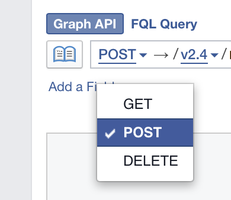

- some POST use cases:
  - post an article onto your wall
    - add `message` field on `me/feed`
  - like a post
    - add `likes` edge on a post node

## Facebook Graph API | Crawling

### > behind the scence

- **API call = HTTP request**
- any programming language that can handle HTTP request is capable of crawling it
- the bottom-right of the Graph API Explorer:

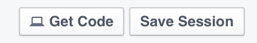

  ```
  curl -i -X GET \
   "https://graph.facebook.com/v2.4/me?fields=context&access_token=CAACEdEose0cBAL34H6NiMZB3ZCnPaZBnShQoSY9GZCh81kDLbQZArxKGEPY…"
  ```

### > Exercise: Get all Metadata Fields of the `me` Node

1. use a library that handles HTTP requests

```r
if ( ! "httr" %in% rownames(installed.packages()) )
    install.packages("httr")
library("httr")
```

2. observe the actuall request made from the Graph API
   - take a look at the `cURL` section from the “get code” button
3. ensemble the request string

```r
# the target API url
api_addr <- "https://graph.facebook.com/v2.4/me"

# a valid token
token <- "CAACEdEose0cBAPZC40ytYxVPs1y2vOm6pL4qcQY8sIVeK6e3ncJzog2ZA5q…"

# build the query string for the GET method
qs <- list(metadata=1, access_token=token)
```

4. make the query

```r
r <- GET(api_addr, query=qs)
```

5. check the response

```r
print(r)
```

```
## Response [https://graph.facebook.com/v2.4/me?metadata=1&access_token=CAACEdEose0cBANFZBRTbr6T3FSQ2XZBFbUMQFH0RveWKJubi76xWbnjnZBB…]
##   Date: 2016-01-22 02:59
##   Status: 200
##   Content-Type: application/json; charset=UTF-8
##   Size: 26.6 kB
```

```r
str(r, max.level=1)
```

```
## List of 10
##  $ url        : chr "https://graph.facebook.com/v2.4/me?metadata=1&access_token=CAACEdEose0cBANFZBRTbr6T3FSQ2XZBFbUMQFH0RveWKJubi76xWbnjnZBBU8xq6nCd"| __truncated__
##  $ status_code: int 200
##  $ headers    :List of 15
##   ..- attr(*, "class")= chr [1:2] "insensitive" "list"
##  $ all_headers:List of 1
##  $ cookies    :'data.frame': 0 obs. of  7 variables:
##  $ content    : raw [1:26581] 7b 22 6e 61 ...
##  $ date       : POSIXct[1:1], format: "2016-01-22 02:59:17"
##  $ times      : Named num [1:6] 0 0.0155 0.017 0.7676 1.0796 ...
##   ..- attr(*, "names")= chr [1:6] "redirect" "namelookup" "connect" "pretransfer" ...
##  $ request    :List of 7
##   ..- attr(*, "class")= chr "request"
##  $ handle     :Class 'curl_handle' <externalptr>
##  - attr(*, "class")= chr "response"
```

6. parse the resulting json data

```r
# parse json
parsed_contents <- content(r) # see ?content for more details
str(parsed_contents, max.level=2)
```

```
## List of 3
##  $ name    : chr "Yueh Hsuan Chung"
##  $ metadata:List of 3
##   ..$ fields     :List of 51
##   ..$ type       : chr "user"
##   ..$ connections:List of 68
##  $ id      : chr "100000862115668"
```

```r
# extract all fields
parsed_contents$metadata$fields %>%
    sapply(function(x) x[["name"]]) %>%
    writeLines
```

```
## id
## about
## age_range
## bio
## birthday
## context
## currency
## devices
## education
## email
## favorite_athletes
## favorite_teams
## first_name
## gender
## hometown
## inspirational_people
## install_type
## installed
## interested_in
## is_shared_login
## is_verified
## languages
## last_name
## link
## location
## locale
## meeting_for
## middle_name
## name
## name_format
## payment_pricepoints
## test_group
## political
## relationship_status
## religion
## security_settings
## significant_other
## sports
## quotes
## third_party_id
## timezone
## token_for_business
## updated_time
## shared_login_upgrade_required_by
## verified
## video_upload_limits
## viewer_can_send_gift
## website
## work
## public_key
## cover
```

```r
# extract all edges (connections)
parsed_contents$metadata$connections %>%
    names %>%
    writeLines
```

```
## favorite_requests
## request_history
## accounts
## achievements
## adaccounts
## adaccountgroups
## adcontracts
## admined_groups
## adnetworkanalytics
## albums
## applications
## apprequests
## apprequestformerrecipients
## books
## brand_teams
## businesses
## businesssettinglogs
## checkins
## commission_splits
## conversations
## domains
## events
## family
## feed
## stream_filters
## friendlists
## friendrequests
## friends
## ids_for_business
## insights
## integrated_plugin_feed
## invitable_friends
## games
## groups
## home
## inbox
## likes
## locations
## movies
## music
```

[output cut: 13 more lines]

```
## pokes
## posts
## privacy_options
## promotable_domains
## promotable_events
## ratings
## scores
## screennames
## taggable_friends
## tagged
## television
## threads
## updates
## videos
## video_broadcasts
```

### > Exercise: Get all Paginated Data

> Scenario: find a post, get a list of names from all users liked it
1. **OBSERVE! OBSERVE! OBSERVE!**
   - pickup a post of yours
   - query the `likes` data on it
     - `<post_id>/likes` or `<post_id>?fields=likes`
   - then what? observe…
     - post without any like
     - post with little likes not paginated
     - post with lots of likes that get paginated
     - the final page for the above kind
   - HINT: use the following query to quickly scan posts with various number of likes
     - `me/posts?fields=likes.limit(1).summary(true)`

=> post without any like

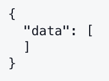

=> post with little likes not paginated

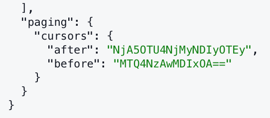

=> post with lots of likes that get paginated

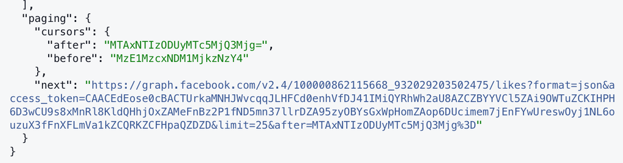

=> the final page for the above kind

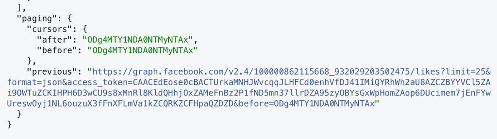

2. write a function to deal with the above data

```r
getAllLikes1 <- function(token, node) {
    require(httr)
    result <- list()
    api_addr <- sprintf("https://graph.facebook.com/v2.4/%s/likes", node)
    qs <- list(fields="name", access_token=token)
    r <- GET(api_addr, query=qs)
    res <- content(r)
    if ( !length(res$data) ) {
        result
    } else {
        result <- c(result, res$data)
        while ( "next" %in% names(res$paging) ) {
            cursor_next <- res$paging$cursors$after
            qs$after <- cursor_next
            r <- GET(api_addr, query=qs)
            res <- content(r)
            result <- c(result, res$data)
        }
        result
    }
}

getAllLikes2 <- function(token, node) {
    result <- list()
    api_addr <- sprintf("https://graph.facebook.com/v2.4/%s/likes", node)
    qs <- list(fields="name", access_token=token)
    r <- GET(api_addr, query=qs)
    res <- content(r)
    if ( !length(res$data) ) {
        result
    } else {
        result <- c(result, res$data)
        while ( "next" %in% names(res$paging) ) {
            next_query <- res$paging$`next`
            r <- GET(next_query)
            res <- content(r)
            result <- c(result, res$data)
        }
        result
    }
}
```

3. check results

```r
node <- "100000862115668_932029203502475"
result1 <- getAllLikes1(token=token, node=node)
result2 <- getAllLikes2(token=token, node=node)
all.equal(result1, result2) # should return T
```

```
## [1] TRUE
```

```r
# tidy into data.frame
head(do.call(rbind, result1))
```

```
##      name           id
## [1,] "Tindy Cheng"  "315371435293768"
## [2,] "ChunKuei Chu" "969673423047100"
## [3,] "林瑋瑋"       "756609997705112"
## [4,] "Mark Yang"    "852448504770317"
## [5,] "蘇中才"       "1487000218"
## [6,] "陳智泓"       "1161704643846945"
```

### > Exercise: The Trending of Likes

1. what do we need?
   - a starting time
   - all post since the starting time with
     - post creating time
     - post likers (preferrably name, id)
2. **OBSERVE!**
   - `me/posts?fields=created_time,likes.fields(id,name)&since=1420070400`
   - don’t forget about the pagination issue
     - posts may be paginated
     - likes per post may be paginated
3. blueprint your program
   - some suggerstions:
     - don’t write a huge function to solve the entire problem
     - try dividing the problem into sub-problems
     - for each sub-problem, write small function to solve it

```r
# think about a blueprint of your craqwler

# need a helper to convert datetime string to timestamp
str2Timestamp <- function(dts) {}

# need a function to crawl all post id in a given time
getPostId <- function(dts, token) {}

# need a function to crawl all like info given a post id
getLikes <- function(pid, token) {}
```

4. implement

```r
# unix time conversion
str2Timestamp <- function(dts)
    as.integer(as.POSIXct(dts, origin="1970-01-01"))

# try it
str2Timestamp("2015-01-01")
```

```
## [1] 1420041600
```

```r
# get post id given a start time
getPostId <- function(dts, token) {
    require(data.table)
    require(magrittr)
    require(httr)
    result <- list()
    api_addr <- "https://graph.facebook.com/v2.4/me/posts"
    qs <- list(since=str2Timestamp(dts), access_token=token)
    r <- GET(api_addr, query=qs)
    res <- content(r)
    if ( !length(res$data) ) {
        result
    } else {
        result <- c(result, res$data)
        while ( "next" %in% names(res$paging) ) {
            next_query <- res$paging$`next`
            r <- GET(next_query)
            res <- content(r)
            result <- c(result, res$data)
        }
        result %<>%
            lapply(function(x) c(time=x$created_time, pid=x$id)) %>%
            do.call(rbind, .) %>%
            as.data.table %>%
            .[, time:=as.POSIXct(time, format="%Y-%m-%dT%H:%M:%S%z")]
        result
    }
}

# try it
getPostId("2015-01-01", token=token) %>% head
```

```
##                   time                              pid
## 1: 2016-01-21 17:11:09 100000862115668_1061898027182258
## 2: 2016-01-19 13:43:22 100000862115668_1060871233951604
## 3: 2016-01-19 03:25:07 100000862115668_1060646857307375
## 4: 2016-01-13 10:21:21 100000862115668_1057543660951028
## 5: 2016-01-11 13:54:39 100000862115668_1056527544385973
## 6: 2016-01-10 22:40:32 100000862115668_1056155424423185
```

```r
# caution!
# one post may have multiple timestamps due to attached photo editing
```

```r
# get likes given a post id
getLikes <- function(pid, token) {
    require(data.table)
    require(magrittr)
    require(httr)
    result <- list()
    fields <- c("id", "name")
    api_addr <- sprintf("https://graph.facebook.com/v2.4/%s/likes?fields=%s",
                        pid, paste(fields, collapse=','))
    qs <- list(access_token=token)
    r <- GET(api_addr, query=qs)
    res <- content(r)
    if ( !length(res$data) ) {
        result
    } else {
        result <- c(result, res$data)
        while ( "next" %in% names(res$paging) ) {
            next_query <- res$paging$`next`
            r <- GET(next_query)
            res <- content(r)
            result <- c(result, res$data)
        }
        result %>% rbindlist %>% cbind(pid=pid)
    }
}

# try it
getLikes(pid=getPostId("2015-01-01", token=token)$pid[1], token=token) %>% head
```

```
##                   id        name                              pid
## 1: 10152101438344021   Chloe Lee 100000862115668_1061898027182258
## 2: 10203196401577752   Teresa Tc 100000862115668_1061898027182258
## 3:        1322255751 Summit Suen 100000862115668_1061898027182258
## 4:   889680407714198      陳宗薊 100000862115668_1061898027182258
```

5. check results

```r
all_posts <- getPostId("2014-01-01", token=token) %>%
    .[, list(time=max(time)), by="pid"]

all_likes <- lapply(all_posts$pid, getLikes, token=token) %>%
    do.call(rbind, .) %>%
    merge(all_posts, by="pid")

head(all_likes)
```

```
##                                 pid                id       name                time
## 1: 100000862115668_1044466062258788 10152414169987377  Allen Lai 2015-12-20 15:59:24
## 2: 100000862115668_1044466062258788   729042290449332     楊承恩 2015-12-20 15:59:24
## 3: 100000862115668_1044466062258788 10204030571792411 Mansun Kuo 2015-12-20 15:59:24
## 4: 100000862115668_1044466062258788        1708592169     王雅人 2015-12-20 15:59:24
## 5: 100000862115668_1044466062258788   681600348569352     施文祥 2015-12-20 15:59:24
## 6: 100000862115668_1044466062258788 10202519467522063     葉祐欣 2015-12-20 15:59:24
```

6. [(not-so) advanced] speed up by parallelizing

```r
library(parallel)

system.time(
    all_likes1 <- lapply(all_posts$pid, getLikes, token=token)
    )
```

```
##    user  system elapsed
##   2.555   0.075  39.829
```

```r
# for Windows guys: parallel by Rscripting
cl <- makeCluster(detectCores())
system.time(
    all_likes2 <- parLapply(cl, all_posts$pid, getLikes, token=token)
    )
```

```
##    user  system elapsed
##   0.006   0.001  11.638
```

```r
stopCluster(cl)

# parallel by forking: *nix only
# system.time(
#     all_likes3 <- mclapply(all_posts$pid, getLikes, token=token,
#                            mc.cores=detectCores())
#     )

all.equal(all_likes1, all_likes2)
```

```
## [1] TRUE
```

7. plot

```r
library(ggplot2)

setorder(all_likes, time)
all_likes <- all_likes[, timed:=as.Date(time)]
all_likes <- all_likes[, timed:=as.Date(time)]
like_trending1 <- all_likes[, list(n_like=.N), by="timed"]
like_trending2 <- all_likes[, list(n_like=.N), by="name,timed"]
top_likes <- all_likes[, list(n_like=.N), by="name"] %>% setorder(-n_like)
```

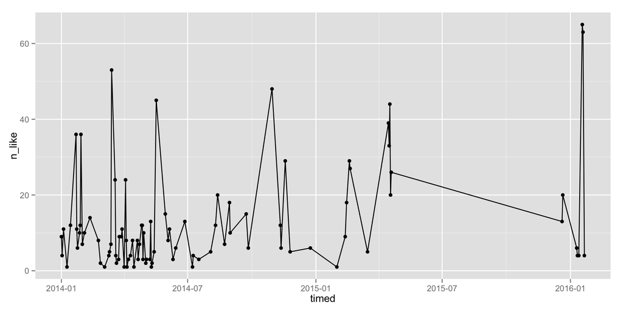

```r
like_trending1 %>%
    ggplot(aes(x=timed, y=n_like)) + geom_line() + geom_point()
```

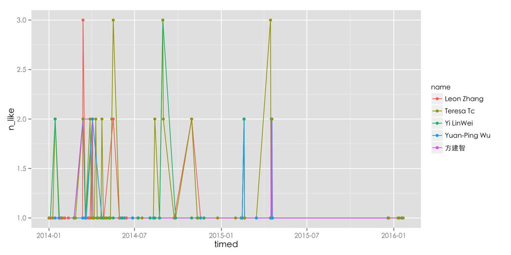

```r
like_trending2[name %in% top_likes$name[1:5]] %>%
    ggplot(aes(x=timed, y=n_like, color=name)) + geom_line() + geom_point() +
    theme(text=element_text(family='Heiti TC Light')) # required to show chinese on OSX
```

### > Exercise: The Warrior of Likes

1. OBSERVE your friends
   - `me/friends`
   - obviously, not all your friends are listed

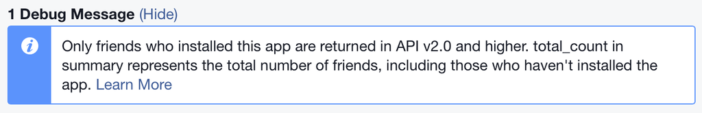

2. any chance to get the user id of an arbitrary person?
   - use your browser: *inspect element*
   - search for keywords like `data-uid` or `uid`

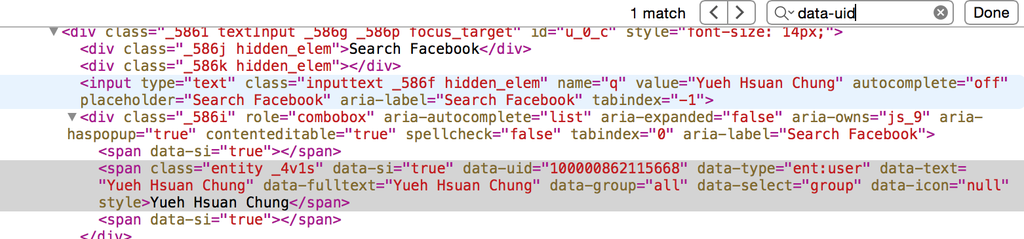

3. OBSERVE the `posts` edge of your friends
   - `<uid>/posts`
   - obviously, not all posts are available *even if it is shared within friends*
   - this is due to the token permission checked
     - BOTH your tokens must grant related permission
4. whatever, let’s crawl your friend list

```r
getFriends <- function(token) {
    require(data.table)
    require(magrittr)
    require(httr)
    result <- list()
    api_addr <- "https://graph.facebook.com/v2.4/me/friends"
    qs <- list(access_token=token)
    r <- GET(api_addr, query=qs)
    res <- content(r)
    if ( !length(res$data) ) {
        result
    } else {
        result <- c(result, res$data)
        while ( "next" %in% names(res$paging) ) {
            next_query <- res$paging$`next`
            r <- GET(next_query)
            res <- content(r)
            result <- c(result, res$data)
        }
        result %>% rbindlist
    }
}

getFriends(token=token) %>% head
```

```
##             name        id
## 1: Han-Wen Chang 348900235
## 2:     Ning Chen 503482470
## 3:        陳奎銘 523887614
## 4:        Pin Wu 524871968
## 5:   Mei-Yu Chen 631698692
## 6:  Linhots Tsao 710176842
```

5. crawl all post id given a friend’s id

```r
getFriendPostId <- function(uid, dts, token) {
    require(data.table)
    require(magrittr)
    require(httr)
    result <- list()
    api_addr <- sprintf("https://graph.facebook.com/v2.4/%s/posts", uid)
    qs <- list(since=str2Timestamp(dts), access_token=token)
    r <- GET(api_addr, query=qs)
    res <- content(r)
    if ( !length(res$data) ) {
        result
    } else {
        result <- c(result, res$data)
        while ( "next" %in% names(res$paging) ) {
            next_query <- res$paging$`next`
            r <- GET(next_query)
            res <- content(r)
            result <- c(result, res$data)
        }
        result %<>%
            lapply(function(x) c(time=x$created_time, pid=x$id)) %>%
            do.call(rbind, .) %>%
            as.data.table %>%
            .[, time:=as.POSIXct(time, format="%Y-%m-%dT%H:%M:%S%z")]
        result
    }
}

getFriendPostId("100000862115668", "2015-01-01", token=token) %>% head
```

```
##                   time                              pid
## 1: 2016-01-21 17:11:09 100000862115668_1061898027182258
## 2: 2016-01-19 13:43:22 100000862115668_1060871233951604
## 3: 2016-01-19 03:25:07 100000862115668_1060646857307375
## 4: 2016-01-13 10:21:21 100000862115668_1057543660951028
## 5: 2016-01-11 13:54:39 100000862115668_1056527544385973
## 6: 2016-01-10 22:40:32 100000862115668_1056155424423185
```

6. crawl posts of all your friends listed on Graph API

```r
all_friends <- getFriends(token=token)

# since it may take some time, let's do it parallel
cl <- makeCluster(detectCores())
clusterExport(cl, "str2Timestamp")
all_friends_posts <- parLapplyLB(cl, all_friends$id, getFriendPostId,
                                 dts="2015-01-01", token=token)
stopCluster(cl)

names(all_friends_posts) <- all_friends$name

post_counts <- sapply(all_friends_posts,
                      function(x) if (!length(x)) 0 else nrow(x))
paste("number of posts available:", names(post_counts), post_counts, sep=" | ") %>%
    head %>%
    write.table(quote=FALSE, row.names=FALSE, col.names=FALSE)
```

```
## number of posts available: | Han-Wen Chang | 0
## number of posts available: | Ning Chen | 0
## number of posts available: | 陳奎銘 | 32
## number of posts available: | Pin Wu | 0
## number of posts available: | Mei-Yu Chen | 259
## number of posts available: | Linhots Tsao | 83
```

7. LIKE them all! (run with caution…)

```r
postLike <- function(pid, token) {
    api_addr <- sprintf("https://graph.facebook.com/v2.4/%s/likes", pid)
    qs <- list(access_token=token)
    r <- POST(api_addr, query=qs)
    r
}

# try it
postArticle <- function(mesg, token) {
    api_addr <- sprintf("https://graph.facebook.com/v2.4/me/feed/")
    r <- POST(api_addr, body=list(access_token=token, message=mesg))
    content(r)
}

# notice that the resulting pid is a compound id in <uid_pid> format
(test_pid <- postArticle("test", token=token))
```

```
## $id
## [1] "100000862115668_1062252643813463"
```

```r
postLike(pid=test_pid, token=token)
```

```
## Response [https://graph.facebook.com/v2.4/100000862115668_1062252643813463/likes?access_token=CAACEdEose0cBANFZBRTbr6T3FSQ2XZBFbUMQFH0RveWKJubi76xWbnjnZBB…]
##   Date: 2016-01-22 03:02
##   Status: 200
##   Content-Type: application/json; charset=UTF-8
##   Size: 16 B
```

```r
# delete the test post
deletePost <- function(pid, token) {
    api_addr <- sprintf("https://graph.facebook.com/v2.4/%s", pid)
    qs <- list(access_token=token)
    r <- DELETE(api_addr, query=qs)
    r
}

deletePost(test_pid, token=token)
```

```
## Response [https://graph.facebook.com/v2.4/100000862115668_1062252643813463?access_token=CAACEdEose0cBANFZBRTbr6T3FSQ2XZBFbUMQFH0RveWKJubi76xWbnjnZBB…]
##   Date: 2016-01-22 03:02
##   Status: 200
##   Content-Type: application/json; charset=UTF-8
##   Size: 16 B
```

```r
# # loop for all posts given a user
# me_id <- "100000862115668"
# all_my_posts <- getFriendPostId(me_id, "2015-01-01", token=token)
# lapply(all_my_posts$pid, postLike, token=token)
```

### Other usage

- [Read your inbox messages](https://github.com/everdark/rcrawler_101/blob/master/inbox.R)

## Regular Expression Basics

### > what is it?

> …a sequence of characters that define a search pattern, mainly for use in pattern matching with strings, or string matching, i.e. “find and replace”-like operations.  
> -wikipedia

### > why we need it?

- sometimes only CSS selector/XPath is not enough
  - contents may not be *structurally* distingushable
  - but can be distinguished by *string pattern*

> 有沒有⋯⋯的八卦？

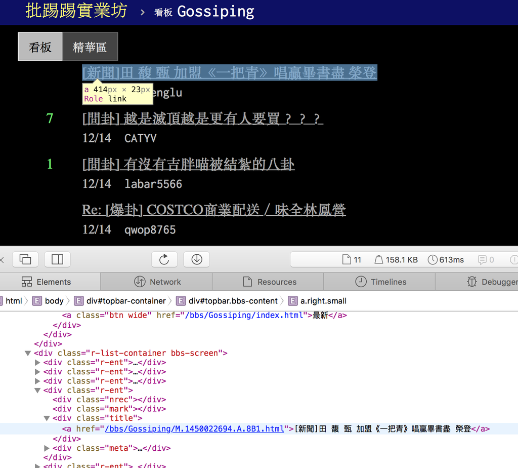

- in the above example, all “title”s are treated *equally* in html structure
  - what if you’d like to only crawl *specific* titles?
  - here comes the Regular Expression!

### > a quick journey

```r
if ( ! "rvest" %in% rownames(installed.packages()) )
    install.packages("rvest")
library("rvest")

# crawl PTT Gossiping article titles
gossip <- GET("https://www.ptt.cc/bbs/Gossiping/index.html",
              set_cookies(over18=1))$content %>% read_html
(
gossip_titles <- gossip %>%
    html_nodes("div .title") %>%
    html_text %>%
    iconv(from="utf8", to="utf8") # for Windows
)
```

[output not shown]

#### >> pattern replacing

- remove unwanted characters

```r
(gossip_titles_cleansed <- gsub("\n\t*", '', gossip_titles))
```

```
##  [1] "Re: [問卦] 有沒有生鐵鍋的八卦"                       "[問卦] 有沒有凌晨三點鐘電視機自己開的八卦"
##  [3] "Re: [新聞] 旅行社接到通知...3月後陸客將銳減三分之一" "Re: [新聞] 「柯市漲」又要錢　搭貓纜70元起跳"
##  [5] "[新聞] 美國這次很挺喔!美智庫:小英已對北京釋"         "Re: [問卦] 台灣對中國的魅力到底在哪裡"
##  [7] "Re: [爆卦] NCC中嘉案公聽會開始了（黃國昌出席）"      "Re: [新聞] 「柯市漲」又要錢　搭貓纜70元起跳"
##  [9] "(本文已被刪除) [kisweet999]"                         "Re: [新聞] 旅行社接到通知...3月後陸客將銳減三分之一"
## [11] "[問卦] 怎樣的景點在座魯宅會一去再去？"               "Re: [問卦] 陸客不來倒楣的到底是誰?"
## [13] "Re: [爆卦] KMT臥底記(?"                              "[新聞] 傳多人因低溫死亡 新北消防：無法斷定"
## [15] "Re: [ＦＢ] 馬英九八年感謝文-林雅強"                  "[問卦] 米國的戰機設計有問題?"
## [17] "[問卦] 400g阿華田的巧克力醬夠肥宅吃幾天?"            "[問卦] 為何中東人會入侵歐洲？"
## [19] "[公告] 八卦板板規(2015.12.01)"                       "Fw: [徵求] 1/20行車紀錄器，九里路上(里港往九如)"
## [21] "Fw: [徵求] 基隆中華路死亡車禍現場監視器或行車記錄器" "[協尋] 1/20台中死亡車禍 徵目擊"
## [23] "[公告] 2016一月置底689閒聊區"
```

#### >> pattern filtering

- search for titles with “[問卦]” only

```r
# something wrong?
grep("[問卦]", gossip_titles_cleansed, value=TRUE)
```

```
##  [1] "Re: [問卦] 有沒有生鐵鍋的八卦"                  "[問卦] 有沒有凌晨三點鐘電視機自己開的八卦"
##  [3] "Re: [問卦] 台灣對中國的魅力到底在哪裡"          "Re: [爆卦] NCC中嘉案公聽會開始了（黃國昌出席）"
##  [5] "[問卦] 怎樣的景點在座魯宅會一去再去？"          "Re: [問卦] 陸客不來倒楣的到底是誰?"
##  [7] "Re: [爆卦] KMT臥底記(?"                         "[問卦] 米國的戰機設計有問題?"
##  [9] "[問卦] 400g阿華田的巧克力醬夠肥宅吃幾天?"       "[問卦] 為何中東人會入侵歐洲？"
## [11] "[公告] 八卦板板規(2015.12.01)"
```

```r
# how about...
grep("\\[問卦\\]", gossip_titles_cleansed, value=TRUE)
```

```
## [1] "Re: [問卦] 有沒有生鐵鍋的八卦"             "[問卦] 有沒有凌晨三點鐘電視機自己開的八卦"
## [3] "Re: [問卦] 台灣對中國的魅力到底在哪裡"     "[問卦] 怎樣的景點在座魯宅會一去再去？"
## [5] "Re: [問卦] 陸客不來倒楣的到底是誰?"        "[問卦] 米國的戰機設計有問題?"
## [7] "[問卦] 400g阿華田的巧克力醬夠肥宅吃幾天?"  "[問卦] 為何中東人會入侵歐洲？"
```

- don’t want reply article!

```r
grep("^\\[問卦\\]", gossip_titles_cleansed, value=TRUE)
```

```
## [1] "[問卦] 有沒有凌晨三點鐘電視機自己開的八卦" "[問卦] 怎樣的景點在座魯宅會一去再去？"
## [3] "[問卦] 米國的戰機設計有問題?"              "[問卦] 400g阿華田的巧克力醬夠肥宅吃幾天?"
## [5] "[問卦] 為何中東人會入侵歐洲？"
```

- only reply article

```r
grep("^Re: ", gossip_titles_cleansed, value=TRUE)
```

```
##  [1] "Re: [問卦] 有沒有生鐵鍋的八卦"                       "Re: [新聞] 旅行社接到通知...3月後陸客將銳減三分之一"
##  [3] "Re: [新聞] 「柯市漲」又要錢　搭貓纜70元起跳"         "Re: [問卦] 台灣對中國的魅力到底在哪裡"
##  [5] "Re: [爆卦] NCC中嘉案公聽會開始了（黃國昌出席）"      "Re: [新聞] 「柯市漲」又要錢　搭貓纜70元起跳"
##  [7] "Re: [新聞] 旅行社接到通知...3月後陸客將銳減三分之一" "Re: [問卦] 陸客不來倒楣的到底是誰?"
##  [9] "Re: [爆卦] KMT臥底記(?"                              "Re: [ＦＢ] 馬英九八年感謝文-林雅強"
```

- titles with ending question mark

```r
grep("？$", gossip_titles_cleansed, value=TRUE)
```

```
## [1] "[問卦] 怎樣的景點在座魯宅會一去再去？" "[問卦] 為何中東人會入侵歐洲？"
```

- titles with any English alphabet

```r
grep("[a-zA-Z]", gossip_titles_cleansed, value=TRUE)
```

```
##  [1] "Re: [問卦] 有沒有生鐵鍋的八卦"                       "Re: [新聞] 旅行社接到通知...3月後陸客將銳減三分之一"
##  [3] "Re: [新聞] 「柯市漲」又要錢　搭貓纜70元起跳"         "Re: [問卦] 台灣對中國的魅力到底在哪裡"
##  [5] "Re: [爆卦] NCC中嘉案公聽會開始了（黃國昌出席）"      "Re: [新聞] 「柯市漲」又要錢　搭貓纜70元起跳"
##  [7] "(本文已被刪除) [kisweet999]"                         "Re: [新聞] 旅行社接到通知...3月後陸客將銳減三分之一"
##  [9] "Re: [問卦] 陸客不來倒楣的到底是誰?"                  "Re: [爆卦] KMT臥底記(?"
## [11] "Re: [ＦＢ] 馬英九八年感謝文-林雅強"                  "[問卦] 400g阿華田的巧克力醬夠肥宅吃幾天?"
## [13] "Fw: [徵求] 1/20行車紀錄器，九里路上(里港往九如)"     "Fw: [徵求] 基隆中華路死亡車禍現場監視器或行車記錄器"
```

### > basic components of RE

- characters (string-literals)
  - `ABCabc123`
- meta-characters (operators)
  - `. ^ $ * + ? { } [ ] \ | ( )`
- special sequences (short-cuts)
  - `\d \D \s \S \w \W \b \B`

#### >> wildcarder: `.`

- match anything
  - *except* newline(`\n`) for *Perl* RE
  - yes there are different versions of RE
  - but the foundementals are essentially the same

```r
test_str <- c("hello world", "你好啊", "\n")
grep('.', test_str, value=TRUE, perl=TRUE)
```

```
## [1] "hello world" "你好啊"
```

```r
grep('.', test_str, value=TRUE, perl=FALSE)
```

```
## [1] "hello world" "你好啊"      "\n"
```

#### >> bounders: `^` and `$`

- `^` limits the begining character
- `$` limits the ending character

```r
grep('^hello', test_str, value=TRUE)
```

```
## [1] "hello world"
```

```r
grep('world$', test_str, value=TRUE)
```

```
## [1] "hello world"
```

```r
grep('^[h你]', test_str, value=TRUE)
```

```
## [1] "hello world" "你好啊"
```

#### >> repeaters: `*`, `+`, and `?`

- `*`: the previous unit must repeat **0 or many times**
- `+`: the previous unit must repeat **1 or many times**
- `?`: the previous unit must repeat **0 or 1 times**

```r
grep("l*", test_str, value=TRUE)
```

```
## [1] "hello world" "你好啊"      "\n"
```

```r
grep("l+", test_str, value=TRUE)
```

```
## [1] "hello world"
```

```r
grep("l?", test_str, value=TRUE)
```

```
## [1] "hello world" "你好啊"      "\n"
```

#### >> advanced repeaters: `{m,n}`

- the previous unit must repeat **at least m times and at most n times**

```r
grep("l{0,10}", test_str, value=TRUE)
```

```
## [1] "hello world" "你好啊"      "\n"
```

```r
grep("l{2}", test_str, value=TRUE)
```

```
## [1] "hello world"
```

```r
grep("l{,2}", test_str, value=TRUE)
```

```
## [1] "hello world" "你好啊"      "\n"
```

```r
grep("l{2,}", test_str, value=TRUE)
```

```
## [1] "hello world"
```

#### >> class: `[]`

- a set of characters that *may* occcur
- meta-char will lose their speacial meaning within it
  - `[0-9$]` matches any of numbers 0 to 9 or the dollar sign($)
  - here the bounder meta-char `$` is treated “as-is”"
  - special meaning only triggered within the class:
- class-specific metas:
  - `-`: ranger
    - e.g., `[0-9a-zA-Z]`
  - `^`: negator
    - e.g., `[^0-9]`

```r
grep("[a-z]", test_str, value=TRUE)
```

```
## [1] "hello world"
```

```r
grep("[0-9]", test_str, value=TRUE)
```

```
## character(0)
```

```r
# want to match the dash (-) ?
grep("[a-z-]", c("abc", "123-456"), value=TRUE)
```

```
## [1] "abc"     "123-456"
```

#### >> grouper: `()`

- to group multiple characters as one unit such that…
  - all other metas will operate on the entire grouped char
  - useful for pattern **match and extraction**

```r
test_str2 <- c("hello", "olleh", "hellohello")
test_str2 %>% grep("^hello$", ., value=TRUE)
```

```
## [1] "hello"
```

```r
test_str2 %>% grep("^[hello]$", ., value=TRUE)
```

```
## character(0)
```

```r
test_str2 %>% grep("^(hello)?$", ., value=TRUE)
```

```
## [1] "hello"
```

```r
test_str2 %>% grep("^(hello)+$", ., value=TRUE)
```

```
## [1] "hello"      "hellohello"
```

#### >> or: `|`

- to qualify one of multiple regex

```r
grep("^h|^你", test_str, value=TRUE)
```

```
## [1] "hello world" "你好啊"
```

#### >> escaper: `\`

- to make its following unit **as-is**
  - the special meaning, if any, is said to be escaped
  - escaper must be *doubled* in R
    - due to language implementation
    - may not be the case for using re in other languageg

```r
grep("^\\^", "^123", value=TRUE)
```

```
## [1] "^123"
```

#### >> other special sequences

- short-cut of specific character classes
- `\d`: any decimal digit => `[0-9]`
- `\D`: any non-digit => `[^0-9]`
- `\s`: any white space => `[ \t\n\r\f\v]`
- `\S`: any non-white space => `[^ \t\n\r\f\v]`
- `\w`: any alphanumeric => `[a-zA-Z0-9_]`
- `\W`: any non-alphanumeric => `[^a-zA-Z0-9_]`
- `\b`: matches the empty string, but only at the beginning or end of a word (`\w`)

## Regular Expression Facilities in R

### > `base::grep` and `base::grepl`

- `grep`: match and return
  - it is vectorized
  - can return either **numeric index** or **original charaters**
  - or return **logical vector** by using `grepl`

```r
# return numeric index
grep("^Re: ", gossip_titles_cleansed)
```

```
##  [1]  1  3  4  6  7  8 10 12 13 15
```

```r
# then can used as selecting vector
gossip_titles_cleansed[grep("^Re: ", gossip_titles_cleansed)]
```

```
##  [1] "Re: [問卦] 有沒有生鐵鍋的八卦"                       "Re: [新聞] 旅行社接到通知...3月後陸客將銳減三分之一"
##  [3] "Re: [新聞] 「柯市漲」又要錢　搭貓纜70元起跳"         "Re: [問卦] 台灣對中國的魅力到底在哪裡"
##  [5] "Re: [爆卦] NCC中嘉案公聽會開始了（黃國昌出席）"      "Re: [新聞] 「柯市漲」又要錢　搭貓纜70元起跳"
##  [7] "Re: [新聞] 旅行社接到通知...3月後陸客將銳減三分之一" "Re: [問卦] 陸客不來倒楣的到底是誰?"
##  [9] "Re: [爆卦] KMT臥底記(?"                              "Re: [ＦＢ] 馬英九八年感謝文-林雅強"
```

```r
# which effectively equals...
grep("^Re: ", gossip_titles_cleansed, value=TRUE)
```

```
##  [1] "Re: [問卦] 有沒有生鐵鍋的八卦"                       "Re: [新聞] 旅行社接到通知...3月後陸客將銳減三分之一"
##  [3] "Re: [新聞] 「柯市漲」又要錢　搭貓纜70元起跳"         "Re: [問卦] 台灣對中國的魅力到底在哪裡"
##  [5] "Re: [爆卦] NCC中嘉案公聽會開始了（黃國昌出席）"      "Re: [新聞] 「柯市漲」又要錢　搭貓纜70元起跳"
##  [7] "Re: [新聞] 旅行社接到通知...3月後陸客將銳減三分之一" "Re: [問卦] 陸客不來倒楣的到底是誰?"
##  [9] "Re: [爆卦] KMT臥底記(?"                              "Re: [ＦＢ] 馬英九八年感謝文-林雅強"
```

```r
# the no-match case
grep("1p3fjhi1o", gossip_titles_cleansed)
```

```
## integer(0)
```

```r
grep("1p3fjhi1o", gossip_titles_cleansed, value=TRUE)
```

```
## character(0)
```

```r
# the fixed patter: no re, all as-is
grep("^Re: ", gossip_titles_cleansed, value=TRUE, fixed=TRUE)
```

```
## character(0)
```

```r
identical(grep("[新聞]", gossip_titles_cleansed, value=TRUE, fixed=TRUE),
          grep("\\[新聞\\]", gossip_titles_cleansed, value=TRUE, fixed=FALSE))
```

```
## [1] TRUE
```

### > `base::gsub`

- **find and replace all**
  - use `sub` to replace only once
- also very useful for **find-and-delete all** scenario

```r
gsub("\\].*", '', gossip_titles_cleansed)
```

```
##  [1] "Re: [問卦"                  "[問卦"                      "Re: [新聞"                  "Re: [新聞"
##  [5] "[新聞"                      "Re: [問卦"                  "Re: [爆卦"                  "Re: [新聞"
##  [9] "(本文已被刪除) [kisweet999" "Re: [新聞"                  "[問卦"                      "Re: [問卦"
## [13] "Re: [爆卦"                  "[新聞"                      "Re: [ＦＢ"                  "[問卦"
## [17] "[問卦"                      "[問卦"                      "[公告"                      "Fw: [徵求"
## [21] "Fw: [徵求"                  "[協尋"                      "[公告"
```

```r
gsub("^.*\\[", '', gossip_titles_cleansed)
```

```
##  [1] "問卦] 有沒有生鐵鍋的八卦"                       "問卦] 有沒有凌晨三點鐘電視機自己開的八卦"
##  [3] "新聞] 旅行社接到通知...3月後陸客將銳減三分之一" "新聞] 「柯市漲」又要錢　搭貓纜70元起跳"
##  [5] "新聞] 美國這次很挺喔!美智庫:小英已對北京釋"     "問卦] 台灣對中國的魅力到底在哪裡"
##  [7] "爆卦] NCC中嘉案公聽會開始了（黃國昌出席）"      "新聞] 「柯市漲」又要錢　搭貓纜70元起跳"
##  [9] "kisweet999]"                                    "新聞] 旅行社接到通知...3月後陸客將銳減三分之一"
## [11] "問卦] 怎樣的景點在座魯宅會一去再去？"           "問卦] 陸客不來倒楣的到底是誰?"
## [13] "爆卦] KMT臥底記(?"                              "新聞] 傳多人因低溫死亡 新北消防：無法斷定"
## [15] "ＦＢ] 馬英九八年感謝文-林雅強"                  "問卦] 米國的戰機設計有問題?"
## [17] "問卦] 400g阿華田的巧克力醬夠肥宅吃幾天?"        "問卦] 為何中東人會入侵歐洲？"
## [19] "公告] 八卦板板規(2015.12.01)"                   "徵求] 1/20行車紀錄器，九里路上(里港往九如)"
## [21] "徵求] 基隆中華路死亡車禍現場監視器或行車記錄器" "協尋] 1/20台中死亡車禍 徵目擊"
## [23] "公告] 2016一月置底689閒聊區"
```

```r
gsub("\\].*|^.*\\[", '', gossip_titles_cleansed)
```

```
##  [1] "問卦"       "問卦"       "新聞"       "新聞"       "新聞"       "問卦"       "爆卦"       "新聞"
##  [9] "kisweet999" "新聞"       "問卦"       "問卦"       "爆卦"       "新聞"       "ＦＢ"       "問卦"
## [17] "問卦"       "問卦"       "公告"       "徵求"       "徵求"       "協尋"       "公告"
```

### > the `stringr` library

- why use it?
  - more intuitive than the built-in RE facilities
  - developed by [Hadley Wickham](https://github.com/hadley/stringr)
    - who also writes `httr`, `ggplot2`, and many others

```r
if ( ! "stringr" %in% rownames(installed.packages()) )
    install.packages("stringr")
library("stringr")
```

#### >> usage: `str_extract` and `str_extract_all`

- to match and full-pattern extract
- can do many-to-many pattern matching, with recycling

```r
# only the matched part will be returned; no-match resolves to NA
str_extract(gossip_titles_cleansed, "\\[問卦\\]")
```

```
##  [1] "[問卦]" "[問卦]" NA       NA       NA       "[問卦]" NA       NA       NA       NA       "[問卦]" "[問卦]"
## [13] NA       NA       NA       "[問卦]" "[問卦]" "[問卦]" NA       NA       NA       NA       NA
```

```r
str_extract(gossip_titles_cleansed, "\\[問卦\\].*")
```

```
##  [1] "[問卦] 有沒有生鐵鍋的八卦"                 "[問卦] 有沒有凌晨三點鐘電視機自己開的八卦"
##  [3] NA                                          NA
##  [5] NA                                          "[問卦] 台灣對中國的魅力到底在哪裡"
##  [7] NA                                          NA
##  [9] NA                                          NA
## [11] "[問卦] 怎樣的景點在座魯宅會一去再去？"     "[問卦] 陸客不來倒楣的到底是誰?"
## [13] NA                                          NA
## [15] NA                                          "[問卦] 米國的戰機設計有問題?"
## [17] "[問卦] 400g阿華田的巧克力醬夠肥宅吃幾天?"  "[問卦] 為何中東人會入侵歐洲？"
## [19] NA                                          NA
## [21] NA                                          NA
## [23] NA
```

```r
str_extract(gossip_titles_cleansed, "^\\[問卦\\] [A-Za-z]+")
```

```
##  [1] NA NA NA NA NA NA NA NA NA NA NA NA NA NA NA NA NA NA NA NA NA NA NA
```

```r
# match (amd extract) multiple times
str_extract_all(gossip_titles_cleansed, "有", simplify=TRUE)
```

```
##       [,1] [,2]
##  [1,] "有" "有"
##  [2,] "有" "有"
##  [3,] ""   ""
##  [4,] ""   ""
##  [5,] ""   ""
##  [6,] ""   ""
##  [7,] ""   ""
##  [8,] ""   ""
##  [9,] ""   ""
## [10,] ""   ""
## [11,] ""   ""
## [12,] ""   ""
## [13,] ""   ""
## [14,] ""   ""
## [15,] ""   ""
## [16,] "有" ""
## [17,] ""   ""
## [18,] ""   ""
## [19,] ""   ""
## [20,] ""   ""
## [21,] ""   ""
## [22,] ""   ""
## [23,] ""   ""
```

```r
# many-to-many pattern matching (with recycling)
str_extract(letters, rep("[a-g]", 26))
```

```
##  [1] "a" "b" "c" "d" "e" "f" "g" NA  NA  NA  NA  NA  NA  NA  NA  NA  NA  NA  NA  NA  NA  NA  NA  NA  NA  NA
```

```r
str_extract(letters, rep("[a-g]", 13))
```

```
##  [1] "a" "b" "c" "d" "e" "f" "g" NA  NA  NA  NA  NA  NA  NA  NA  NA  NA  NA  NA  NA  NA  NA  NA  NA  NA  NA
```

```r
str_extract(letters, rep("[a-g]", 52))
```

```
##  [1] "a" "b" "c" "d" "e" "f" "g" NA  NA  NA  NA  NA  NA  NA  NA  NA  NA  NA  NA  NA  NA  NA  NA  NA  NA  NA  "a" "b" "c"
## [30] "d" "e" "f" "g" NA  NA  NA  NA  NA  NA  NA  NA  NA  NA  NA  NA  NA  NA  NA  NA  NA  NA  NA
```

#### >> usage: `str_match` and `str_match_all`

- to match and partial-pattern extract
- returned object is in compact matrix form

```r
# without grouper
str_match(gossip_titles_cleansed, "\\[.*\\]")
```

```
##       [,1]
##  [1,] "[問卦]"
##  [2,] "[問卦]"
##  [3,] "[新聞]"
##  [4,] "[新聞]"
##  [5,] "[新聞]"
##  [6,] "[問卦]"
##  [7,] "[爆卦]"
##  [8,] "[新聞]"
##  [9,] "[kisweet999]"
## [10,] "[新聞]"
## [11,] "[問卦]"
## [12,] "[問卦]"
## [13,] "[爆卦]"
## [14,] "[新聞]"
## [15,] "[ＦＢ]"
## [16,] "[問卦]"
## [17,] "[問卦]"
## [18,] "[問卦]"
## [19,] "[公告]"
## [20,] "[徵求]"
## [21,] "[徵求]"
## [22,] "[協尋]"
## [23,] "[公告]"
```

```r
# with grouper
str_match(gossip_titles_cleansed, "\\[(.*)\\]")
```

```
##       [,1]           [,2]
##  [1,] "[問卦]"       "問卦"
##  [2,] "[問卦]"       "問卦"
##  [3,] "[新聞]"       "新聞"
##  [4,] "[新聞]"       "新聞"
##  [5,] "[新聞]"       "新聞"
##  [6,] "[問卦]"       "問卦"
##  [7,] "[爆卦]"       "爆卦"
##  [8,] "[新聞]"       "新聞"
##  [9,] "[kisweet999]" "kisweet999"
## [10,] "[新聞]"       "新聞"
## [11,] "[問卦]"       "問卦"
## [12,] "[問卦]"       "問卦"
## [13,] "[爆卦]"       "爆卦"
## [14,] "[新聞]"       "新聞"
## [15,] "[ＦＢ]"       "ＦＢ"
## [16,] "[問卦]"       "問卦"
## [17,] "[問卦]"       "問卦"
## [18,] "[問卦]"       "問卦"
## [19,] "[公告]"       "公告"
## [20,] "[徵求]"       "徵求"
## [21,] "[徵求]"       "徵求"
## [22,] "[協尋]"       "協尋"
## [23,] "[公告]"       "公告"
```

```r
str_match(gossip_titles_cleansed, "Re: \\[(.*)\\]")
```

```
##       [,1]         [,2]
##  [1,] "Re: [問卦]" "問卦"
##  [2,] NA           NA
##  [3,] "Re: [新聞]" "新聞"
##  [4,] "Re: [新聞]" "新聞"
##  [5,] NA           NA
##  [6,] "Re: [問卦]" "問卦"
##  [7,] "Re: [爆卦]" "爆卦"
##  [8,] "Re: [新聞]" "新聞"
##  [9,] NA           NA
## [10,] "Re: [新聞]" "新聞"
## [11,] NA           NA
## [12,] "Re: [問卦]" "問卦"
## [13,] "Re: [爆卦]" "爆卦"
## [14,] NA           NA
## [15,] "Re: [ＦＢ]" "ＦＢ"
## [16,] NA           NA
## [17,] NA           NA
## [18,] NA           NA
## [19,] NA           NA
## [20,] NA           NA
## [21,] NA           NA
## [22,] NA           NA
## [23,] NA           NA
```

```r
str_match(gossip_titles_cleansed, "\\[(.?)(.?)\\]")
```

```
##       [,1]     [,2] [,3]
##  [1,] "[問卦]" "問" "卦"
##  [2,] "[問卦]" "問" "卦"
##  [3,] "[新聞]" "新" "聞"
##  [4,] "[新聞]" "新" "聞"
##  [5,] "[新聞]" "新" "聞"
##  [6,] "[問卦]" "問" "卦"
##  [7,] "[爆卦]" "爆" "卦"
##  [8,] "[新聞]" "新" "聞"
##  [9,] NA       NA   NA
## [10,] "[新聞]" "新" "聞"
## [11,] "[問卦]" "問" "卦"
## [12,] "[問卦]" "問" "卦"
## [13,] "[爆卦]" "爆" "卦"
## [14,] "[新聞]" "新" "聞"
## [15,] "[ＦＢ]" "Ｆ" "Ｂ"
## [16,] "[問卦]" "問" "卦"
## [17,] "[問卦]" "問" "卦"
## [18,] "[問卦]" "問" "卦"
## [19,] "[公告]" "公" "告"
## [20,] "[徵求]" "徵" "求"
## [21,] "[徵求]" "徵" "求"
## [22,] "[協尋]" "協" "尋"
## [23,] "[公告]" "公" "告"
```

```r
# mathc once or many times
gossip_titles_cleansed %>% head %>% str_match("[a-z]")
```

```
##      [,1]
## [1,] "e"
## [2,] NA
## [3,] "e"
## [4,] "e"
## [5,] NA
## [6,] "e"
```

```r
gossip_titles_cleansed %>% head %>% str_match_all("[a-z]")
```

```
## [[1]]
##      [,1]
## [1,] "e"
##
## [[2]]
##      [,1]
##
## [[3]]
##      [,1]
## [1,] "e"
##
## [[4]]
##      [,1]
## [1,] "e"
##
## [[5]]
##      [,1]
##
## [[6]]
##      [,1]
## [1,] "e"
```

### > Exercise: PTT Gossiping Pattern Match

```r
# make a comprehensive function for multi-page crawling
crawlPttTitles <- function(npage, pat, target="Gossiping") {

    require(data.table)
    require(parallel)
    require(stringr)
    require(rvest)
    require(httr)

    # make it fast by parallelling
    cl <- makeCluster(detectCores())
    on.exit(stopCluster(cl))

    # crawl front page
    response <- GET(sprintf("https://www.ptt.cc/bbs/%s/index.html", target),
                  set_cookies(over18=1))
    if ( (rcode <- response$status_code) != 200 )
        stop(sprintf("Got status code %s.", rcode))

    # get page index
    lastpage_idx <- response$content %>% read_html %>%
        html_nodes("div .btn.wide") %>%
        iconv(from="utf8", to="utf8") %>% # for Windows
        grep("上頁", ., value=TRUE) %>% {
            as.integer(str_match(., "index([0-9]+)\\.html")[,2])
        }
    all_pages <- sprintf("https://www.ptt.cc/bbs/%s/index%s.html",
                         target, (lastpage_idx+1):(lastpage_idx-npage+2))

    # grep titles with given regex
    oneshot <- function(page_url, pat) {
        require(data.table)
        require(rvest)
        require(httr)
        ptt <- GET(page_url, set_cookies(over18=1))$content %>% read_html
        # deleted posts dont have <a href></a>
        not_deleted <- html_nodes(ptt, "div .title") %>%
            as.character %>%
            grepl("<a href", .)
        titles <- html_nodes(ptt, "div .title") %>%
            html_text %>%
            iconv(from="utf8", to="utf8") %>% # for Windows
            gsub("\n\t*", '', .) %>%
            .[not_deleted]
        links <- html_nodes(ptt, "div .title a") %>%
            html_attr("href") %>%
            iconv(from="utf8", to="utf8") # for Windows
        nrec <- html_nodes(ptt, "div .nrec") %>%
            html_text %>%
            iconv(from="utf8", to="utf8") %>% # for Windows
            .[not_deleted]
        res <- data.table(nrec=nrec, title=titles, link=links) %>%
            .[grepl(pat, title)]
        res
    }
    res <- parLapplyLB(cl, all_pages, oneshot, pat=pat)
    res[sapply(res, function(x) length(x) > 0)] %>% rbindlist
}

# check result
system.time(
    wanted <- crawlPttTitles(1000, "^\\[問卦\\] 有沒有.*的八卦[？?]")
)
```

```
##    user  system elapsed
##   0.295   0.036  45.860
```

```r
wanted %>% head
```

```
##    nrec                                title                                   link
## 1:          [問卦] 有沒有當完兵後變笨的八卦? /bbs/Gossiping/M.1453480878.A.2ED.html
## 2:   11      [問卦] 有沒有寒流還沒來的八卦？ /bbs/Gossiping/M.1453480326.A.095.html
## 3:    6 [問卦] 有沒有冬季到台北來看雪的八卦? /bbs/Gossiping/M.1453480570.A.B1E.html
## 4:    9       [問卦] 有沒有漢字拉丁化的八卦? /bbs/Gossiping/M.1453479929.A.654.html
## 5:    6             [問卦] 有沒有冰雨的八卦? /bbs/Gossiping/M.1453480272.A.94F.html
## 6:            [問卦] 有沒有非洲螢火蟲的八卦? /bbs/Gossiping/M.1453479677.A.670.html
```

```r
# tidy result
wanted <- wanted[grep("爆", nrec), cnt := 150L] %>%
    .[grep("^X", nrec), cnt := 0L] %>%
    .[nrec == '', cnt := 0L] %>%
    .[is.na(cnt), cnt:=as.integer(nrec)]
```

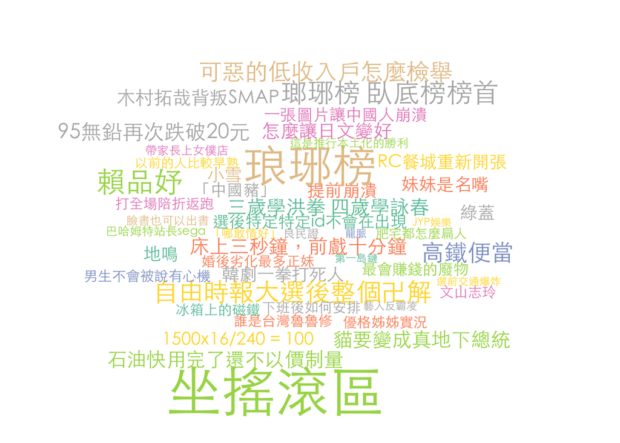

```r
# not enough? let's do some visualization
library(RColorBrewer)
library(wordcloud)
buzz <- str_match(wanted$title, "有沒有(.*)的八卦？")[,2] %T>%
    {
        par(family='Heiti TC Light')
        wordcloud(., wanted$cnt, min.freq=3, scale=c(4,.5),
                  rot.per=0, fixed.asp=FALSE,
                  colors=brewer.pal(8, name="Set2"), random.color=TRUE)
    }
```

### > Exercise: PTT Moive Tagging

```r
ptt_movie <- crawlPttTitles(1000, "^\\[.*雷\\]", "movie")

rei <- str_match(ptt_movie$title, "^\\[(.*)雷\\]《(.*)》") %>%
    .[!is.na(.[,1]),-1] %>%
    as.data.table %>% {
        setnames(., c("rei", "title"))
        setorder(., title)
        .[, list(.N), by="title,rei"]
    }
head(rei, 20) %>% write.table(row.names=FALSE, col.names=FALSE, quote=FALSE)
```

```
##  絕地救援 The Martian  好 1
## 007惡魔四伏 負 1
## 007：惡魔四伏 普 1
## 45年 好 1
## 52個星期二 好 1
## Inside Out 好 1
## 三心一意 好 1
## 久美子的奇異旅程 普 1
## 他媽媽的藏寶圖 負無 1
## 侏羅紀公園 有 1
## 保全員之死 屌 1
## 全家玩到趴 普 1
## 再見，在也不見 普 1
## 別跟山過不去 普 1
## 刺客聶隱娘 普 1
## 劇場靈 普 1
## 危樓愚夫 超好 1
## 原力覺醒 好微 1
## 可惜不是 大負 1
## 命運．晚餐 普好 1
```

### > Exercise: Dcard Article Crawling

- Title only

```r
crawlDcardTitles <- function(target="bg", npage, pat) {

    require(data.table)
    require(parallel)
    require(stringr)
    require(rvest)
    require(httr)

    cl <- makeCluster(detectCores())
    on.exit(stopCluster(cl))

    pages <- sprintf("https://www.dcard.tw/api/forum/%s/%s", target, 1:npage)

    crawlSinglePage <- function(page_url, pat) {
        require(data.table)
        require(rvest)
        require(httr)
        response <- GET(page_url)
        if ( (rcode <- response$status_code) != 200 ) {
            NULL
        } else {
            content(response) %>%
                sapply(function(x) x$version[[1]]$title) %>%
                grep(pat, ., value=TRUE)
        }
    }
    parLapplyLB(cl, pages, crawlSinglePage, pat=pat) %>% unlist
}

system.time(
    dcardtitles <- crawlDcardTitles("bg", 1000, "室友")
)
```

```
##    user  system elapsed
##   0.020   0.015  62.509
```

```r
dcardtitles # rarer than what I thought...
```

```
## [1] "救救綠光室友"
```

- Dig into contents of articles

```r
crawlDcardArticles <- function(target="bg", npage,
                               title_pat=NULL, article_pat, npat) {

    require(parallel)
    require(rvest)
    require(httr)

    cl <- makeCluster(detectCores())
    on.exit(stopCluster(cl))

    pages <- sprintf("https://www.dcard.tw/api/forum/%s/%s", target, 1:npage)

    crawlSinglePageTitleId <- function(page_url, pat) {
        require(rvest)
        require(httr)
        response <- GET(page_url)
        if ( (rcode <- response$status_code) != 200 ) {
            NULL
        } else {
            json <- content(response)
            if ( !is.null(pat) ) {
                idx <- sapply(json, function(x) x$version[[1]]$title) %>%
                    grep(pat, .)
                sapply(json[idx], function(x) x$id)
            } else {
                content(response) %>% sapply(function(x) x$id)
            }
        }
    }

    crawlSingleArticle <- function(page_url, pat, npat) {
        require(stringr)
        require(rvest)
        require(httr)
        response <- GET(page_url)
        if ( (rcode <- response$status_code) != 200 ) {
            NULL
        } else {
            json <- content(response)
            matched_len <- json$version[[1]]$content %>%
                str_match_all(pat) %>%
                unlist %>%
                length
            if  ( matched_len >= npat ) {
                json$version[[1]]$content
            } else {
                NULL
            }
        }
    }

    parLapplyLB(cl, pages, crawlSinglePageTitleId, pat=title_pat) %>%
        unlist %>%
        sprintf("https://www.dcard.tw/api/post/%s/%s", target, .) %>%
        parLapplyLB(cl, ., crawlSingleArticle,
                    pat=article_pat, npat=npat) %>%
        unlist
}

system.time(
    dcardarticles <- crawlDcardArticles("bg", 100, article_pat="室友", npat=3)
)
```

```
##    user  system elapsed
##   0.024   0.013  76.582
```

```r
length(dcardarticles)
```

```
## [1] 5
```

```r
dcardarticles %>% head %>% substr(start=1, stop=100)
```

```
## [1] "不知道是不是發男女版,但有涉及到男男女女,所以我就發這了\n\n曾經我跟一個女孩L在一起\n一開始我對她沒有任何感覺,就跟普通朋友一樣\n但她常常約我,跟我聊天...\n讓我慢慢地對她也有好感\n於是我就答應了她"
## [2] "在一次聚會中認識了你\n之後了解你很擅長交朋友而且男女都有\n是個很細心的男生\n\n後來我們\n一個禮拜有四堂共同課\n幾乎有三堂他會坐在我旁邊\n會幫對方互相留位子，翹課時也相互照應\n有時上課他會突然靠得很近，"
## [3] "看著Dcard上分享當小三遇小三養小三的文章 \n觸碰到內心深處的記憶\n\n時間可以沖淡一切\n但在深陷泥沼中 總是不知不覺向下陷\n\n-----------------正文開始---------------"
## [4] "手機排版請見諒\n\n在開始講故事以前\n我要先說說故事的背景\n我的還有她的\n\n我是一個魯了差點超過20年體重突破三位數的魯蛇(ps胖子朋友不要放棄啊冬天是你的主場！！！！\n一個台獨分子\n\n她是來從大陸來台"
## [5] "首po手機排版請見諒\U0001f60f\n上大學後,每天在狄卡爬文抽卡是小大一的必經之路。12點一過和室友討論誰抽到的卡友也是生活當中的樂趣。然而不知道是狄卡設計還是什麼的,總覺得我們寢室常被銃鏮。\n\n        "
```

## References

- Facebook Graph API [official doc](https://developers.facebook.com/docs/graph-api)
- [stringr vignettes](https://cran.r-project.org/web/packages/stringr/vignettes/stringr.html)
- [httr quickstart guide](https://cran.r-project.org/web/packages/httr/vignettes/quickstart.html)
- [magrittr vignettes](https://cran.r-project.org/web/packages/magrittr/vignettes/magrittr.html)

## Other Useful Materials

- learning R: a programmer-oriented introduction
  - [everdark/lecture_rintro](http://everdark.github.io/lecture_rintro/)
- learning `data.table`
  - [mansunkuo/dsc2015_data.table](http://mansunkuo.github.io/dsc2015_data.table/#1)
  - [the data.table cheatsheet](http://www.r-bloggers.com/the-data-table-cheat-sheet/)
- learning `ggplot2`
  - [everdark/ggplot2_lecture_dsc2015](http://everdark.github.io/ggplot2_lecture_dsc2015/)
- similar materials but in Python
  - [everdark/pycrawler_101](http://everdark.github.io/pycrawler_101/#/)